# Does Money Buy Happiness

## Introduction

What makes a country happy? Is it money? Is it the people? Is it the government? In this project I aim to demonstrate the data science pipeline using the World Happiness Index and answer a question. Like the famously misattributed quote to John Lennon, "I want to grow up to be happy", many of us desire to be happy as we grow older. As we age, that usually brings with it financial freedom to travel or expend it on other ways for ourselves. Whatever the case, we should know what makes us happy before we decide to spend it.

That's where this dataset comes in! We're gonna look over a span of years to see if over time money has made people happier. For countries with an increase in GDP (Gross Domestic Product/Overview for how well the country is doing) did they report an increase score in happiness.

Along the way, we will also learn about the data science pipeline so lets begin!

```python
# Let's start out by importing some useful libraries.
# Import them as the abbreviation for ease of writing later (though this isn't necessary).

import pandas as pd
import numpy as np
import matplotlib.pyplot as plt
import seaborn as sns
```

## Data Collection

```python
# First we simply read in the data using pandas
data15 = pd.read_csv('archive/2015.csv')
data16 = pd.read_csv('archive/2016.csv')
data17 = pd.read_csv('archive/2017.csv')
data18 = pd.read_csv('archive/2018.csv')
data19 = pd.read_csv('archive/2019.csv')
```

```python
data15
```

|  | Country | Region | Happiness Rank | Happiness Score | Standard Error | Economy (GDP per Capita) | Family | Health (Life Expectancy) | Freedom | Trust (Government Corruption) | Generosity | Dystopia Residual |
| --- | --- | --- | --- | --- | --- | --- | --- | --- | --- | --- | --- | --- |
| 0 | Switzerland | Western Europe | 1 | 7.587 | 0.03411 | 1.39651 | 1.34951 | 0.94143 | 0.66557 | 0.41978 | 0.29678 | 2.51738 |
| 1 | Iceland | Western Europe | 2 | 7.561 | 0.04884 | 1.30232 | 1.40223 | 0.94784 | 0.62877 | 0.14145 | 0.43630 | 2.70201 |
| 2 | Denmark | Western Europe | 3 | 7.527 | 0.03328 | 1.32548 | 1.36058 | 0.87464 | 0.64938 | 0.48357 | 0.34139 | 2.49204 |
| 3 | Norway | Western Europe | 4 | 7.522 | 0.03880 | 1.45900 | 1.33095 | 0.88521 | 0.66973 | 0.36503 | 0.34699 | 2.46531 |
| 4 | Canada | North America | 5 | 7.427 | 0.03553 | 1.32629 | 1.32261 | 0.90563 | 0.63297 | 0.32957 | 0.45811 | 2.45176 |
| ... | ... | ... | ... | ... | ... | ... | ... | ... | ... | ... | ... | ... |
| 153 | Rwanda | Sub-Saharan Africa | 154 | 3.465 | 0.03464 | 0.22208 | 0.77370 | 0.42864 | 0.59201 | 0.55191 | 0.22628 | 0.67042 |
| 154 | Benin | Sub-Saharan Africa | 155 | 3.340 | 0.03656 | 0.28665 | 0.35386 | 0.31910 | 0.48450 | 0.08010 | 0.18260 | 1.63328 |
| 155 | Syria | Middle East and Northern Africa | 156 | 3.006 | 0.05015 | 0.66320 | 0.47489 | 0.72193 | 0.15684 | 0.18906 | 0.47179 | 0.32858 |
| 156 | Burundi | Sub-Saharan Africa | 157 | 2.905 | 0.08658 | 0.01530 | 0.41587 | 0.22396 | 0.11850 | 0.10062 | 0.19727 | 1.83302 |
| 157 | Togo | Sub-Saharan Africa | 158 | 2.839 | 0.06727 | 0.20868 | 0.13995 | 0.28443 | 0.36453 | 0.10731 | 0.16681 | 1.56726 |

158 rows × 12 columns

```python
data19.head()
```

|  | Overall rank | Country or region | Score | GDP per capita | Social support | Healthy life expectancy | Freedom to make life choices | Generosity | Perceptions of corruption |
| --- | --- | --- | --- | --- | --- | --- | --- | --- | --- |
| 0 | 1 | Finland | 7.769 | 1.340 | 1.587 | 0.986 | 0.596 | 0.153 | 0.393 |
| 1 | 2 | Denmark | 7.600 | 1.383 | 1.573 | 0.996 | 0.592 | 0.252 | 0.410 |
| 2 | 3 | Norway | 7.554 | 1.488 | 1.582 | 1.028 | 0.603 | 0.271 | 0.341 |
| 3 | 4 | Iceland | 7.494 | 1.380 | 1.624 | 1.026 | 0.591 | 0.354 | 0.118 |
| 4 | 5 | Netherlands | 7.488 | 1.396 | 1.522 | 0.999 | 0.557 | 0.322 | 0.298 |

Awesome! So now we got our data into a dataframe and we can work with it. We really only care about GDP, country and score so we can drop the others. Let's change some of the column names to something better.

```python
# Best to simply the column names to save writing time and having to double check what they were

# Some of the datasets had slightly different column names
data15.rename(columns = {"Happiness Rank": "rank",
                         "Country": "country",
                         "Happiness Score": "score",
                         "Economy (GDP per Capita)": "gdp_per_cap"
                         }, inplace=True)

data16.rename(columns = {"Happiness Rank": "rank",
                         "Country": "country",
                         "Happiness Score": "score",
                         "Economy (GDP per Capita)": "gdp_per_cap"
                        }, inplace=True)

data17.rename(columns = {"Happiness.Rank": "rank",
                         "Country": "country",
                         "Happiness.Score": "score",
                         "Economy..GDP.per.Capita.": "gdp_per_cap"
                        }, inplace=True)

data18.rename(columns = {"Overall rank": "rank",
                         "Country or region": "country",
                         "Score": "score",
                         "GDP per capita": "gdp_per_cap"
                        }, inplace=True)

data19.rename(columns = {"Overall rank": "rank",
                         "Country or region": "country",
                         "Score": "score",
                         "GDP per capita": "gdp_per_cap"
                        }, inplace=True)
```

```python
data19.describe(include='all')
```

|  | rank | country | score | gdp_per_cap | Social support | Healthy life expectancy | Freedom to make life choices | Generosity | Perceptions of corruption |
| --- | --- | --- | --- | --- | --- | --- | --- | --- | --- |
| count | 156.000000 | 156 | 156.000000 | 156.000000 | 156.000000 | 156.000000 | 156.000000 | 156.000000 | 156.000000 |
| unique | NaN | 156 | NaN | NaN | NaN | NaN | NaN | NaN | NaN |
| top | NaN | Romania | NaN | NaN | NaN | NaN | NaN | NaN | NaN |
| freq | NaN | 1 | NaN | NaN | NaN | NaN | NaN | NaN | NaN |
| mean | 78.500000 | NaN | 5.407096 | 0.905147 | 1.208814 | 0.725244 | 0.392571 | 0.184846 | 0.110603 |
| std | 45.177428 | NaN | 1.113120 | 0.398389 | 0.299191 | 0.242124 | 0.143289 | 0.095254 | 0.094538 |
| min | 1.000000 | NaN | 2.853000 | 0.000000 | 0.000000 | 0.000000 | 0.000000 | 0.000000 | 0.000000 |
| 25% | 39.750000 | NaN | 4.544500 | 0.602750 | 1.055750 | 0.547750 | 0.308000 | 0.108750 | 0.047000 |
| 50% | 78.500000 | NaN | 5.379500 | 0.960000 | 1.271500 | 0.789000 | 0.417000 | 0.177500 | 0.085500 |
| 75% | 117.250000 | NaN | 6.184500 | 1.232500 | 1.452500 | 0.881750 | 0.507250 | 0.248250 | 0.141250 |
| max | 156.000000 | NaN | 7.769000 | 1.684000 | 1.624000 | 1.141000 | 0.631000 | 0.566000 | 0.453000 |

Now let's drop those columns we don't need.

```python
# We're also going to include a new column for the year to help when we concat all these dataframes together
data15 = data15[['country','score', 'gdp_per_cap']]
data15['year'] = 2015

data16 = data16[['country', 'score', 'gdp_per_cap']]
data16['year'] = 2016

data17 = data17[['country', 'score', 'gdp_per_cap']]
data17['year'] = 2017

data18 = data18[['country','score', 'gdp_per_cap']]
data18['year'] = 2018

data19 = data19[['country','score', 'gdp_per_cap']]
data19['year'] = 2019
```

Now we want to only look at countries that have improved their GDP from 2015 to 2019 overall (if they dipped inbetween that time it does not matter).

```python
# First, let's get all the countries from 2019 into a set
# We will use this later
# We use a set over a list as it has an O(1) lookup and it will be more efficient for us

#To learn more about sets check out: https://docs.python.org/3/c-api/set.html
countries19 = set()
for i in data19.country.unique():
    countries19.add(i)
```

```python
# We're only going to look at the countries that increased their gdp from 2015 to 2019 (in between doesn't matter just overall did they improve)

# We're creating an increasing column to show which countries increased
# First we check that the country is in the 2019 or else it will throw an error (we return false and say it does not increase instead)
# Next we compare the gdp of 2015 to 2019

# Originally the code was written like data19[data19['country']== row['country']]['gdp_per_cap'] but ran into errors due to how pandas handles chain indexing and assigning
# Take a look at https://pandas.pydata.org/pandas-docs/stable/user_guide/indexing.html#returning-a-view-versus-a-copy
# For more information about why my old way won't

data15['inc'] =  data15.apply(lambda row: row['country'] in countries19 and row['gdp_per_cap'] < data19.loc[data19['country']== row['country'], ['gdp_per_cap']].iloc[0] , axis =1 )
```

```python
# Now we only want the  countries whose wealth  increased
data15 = data15[data15['inc']]
data15
```

|  | country | score | gdp_per_cap | year | inc |
| --- | --- | --- | --- | --- | --- |
| 0 | Switzerland | 7.587 | 1.39651 | 2015 | True |
| 1 | Iceland | 7.561 | 1.30232 | 2015 | True |
| 2 | Denmark | 7.527 | 1.32548 | 2015 | True |
| 3 | Norway | 7.522 | 1.45900 | 2015 | True |
| 4 | Canada | 7.427 | 1.32629 | 2015 | True |
| ... | ... | ... | ... | ... | ... |
| 152 | Afghanistan | 3.575 | 0.31982 | 2015 | True |
| 153 | Rwanda | 3.465 | 0.22208 | 2015 | True |
| 154 | Benin | 3.340 | 0.28665 | 2015 | True |
| 156 | Burundi | 2.905 | 0.01530 | 2015 | True |
| 157 | Togo | 2.839 | 0.20868 | 2015 | True |

137 rows × 5 columns

Great! We dropped about 20 countries and now we can get to it.

```python
# Now we're going to fix the other tables using a similar method from before
countries15 = set()
for i in data15.country.unique():
    countries15.add(i)
```

```python
# Combine them all together
df = pd.concat(
    [ data15,
    data16[data16.country.isin(countries15)],
    data17[data17.country.isin(countries15)],
    data18[data18.country.isin(countries15)],
    data19[data19.country.isin(countries15)],
    ]
    )
```

```python
df
```

|  | country | score | gdp_per_cap | year | inc |
| --- | --- | --- | --- | --- | --- |
| 0 | Switzerland | 7.587 | 1.39651 | 2015 | True |
| 1 | Iceland | 7.561 | 1.30232 | 2015 | True |
| 2 | Denmark | 7.527 | 1.32548 | 2015 | True |
| 3 | Norway | 7.522 | 1.45900 | 2015 | True |
| 4 | Canada | 7.427 | 1.32629 | 2015 | True |
| ... | ... | ... | ... | ... | ... |
| 147 | Botswana | 3.488 | 1.04100 | 2019 | NaN |
| 149 | Malawi | 3.410 | 0.19100 | 2019 | NaN |
| 151 | Rwanda | 3.334 | 0.35900 | 2019 | NaN |
| 152 | Tanzania | 3.231 | 0.47600 | 2019 | NaN |
| 153 | Afghanistan | 3.203 | 0.35000 | 2019 | NaN |

675 rows × 5 columns

# Data Representation and Analysis

Now let's plot so that we can see what our data looks like!

[figure not shown]

```python
# use figsize to increase the size for more visibility
plt.subplots(figsize = (8,8))
# use plt.scatter to plot
plt.scatter(df.year,df.score)
plt.xlabel("Year")
plt.ylabel("Happiness score")
plt.title("Happiness over GDP")
plt.show()
```

Now let's take a look at the distribution of the happiness score using violinplots

Check out https://matplotlib.org/stable/api/_as_gen/matplotlib.axes.Axes.violinplot.html for more info on violinplots.

```python
# First we should put all the data into a array then add them to a list.  Then we get the unique years.
happy_score = []
for i in df['year'].unique():
    year = np.asarray(df.loc[df['year'] == i]['score'])
    happy_score.append(year)
happy_score
years = np.asarray(df['year'].unique())
```

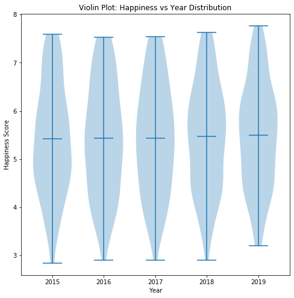

```python
plt.subplots(figsize = (8,8))
plt.violinplot(happy_score,years,widths=.75,showmeans=True, )
plt.title("Violin Plot: Happiness vs Year Distribution")
plt.xlabel("Year")
plt.ylabel("Happiness Score")
# plt.title("Violin Plot Example")
plt.savefig("violin.png")
```

The means over the years seem to be roughly the same and the scores seem to have a normal distribution.

[figure not shown]

```python
# Let's take a look at Gdp over the years
plt.subplots(figsize = (8,8))

plt.scatter(df.year, df.gdp_per_cap)
plt.xlabel("Freedom of to make life Choices")
plt.ylabel("Happiness score")
plt.title("Happiness over Freedom")
plt.show()
```

```python
gdp_score = []
for i in df['year'].unique():
    year = np.asarray(df.loc[df['year'] == i]['gdp_per_cap'])
    gdp_score.append(year)
```

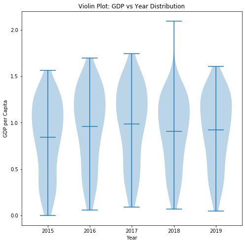

```python
plt.subplots(figsize = (8,8))
plt.violinplot(gdp_score,years,widths=.75,showmeans=True, )
plt.title("Violin Plot: GDP vs Year Distribution")
plt.xlabel("Year")
plt.ylabel("GDP per Capita")
# plt.title("Violin Plot Example")
plt.savefig("violin.png")
```

GDP over years seems to tell a similar story though there is much more variation in terms of GDP across the years.

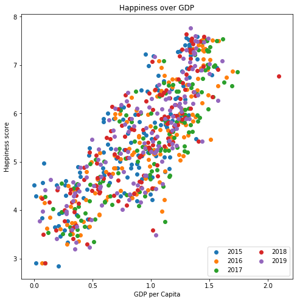

```python
# Now let's plot all the points and see if we can see any trends
plt.subplots(figsize = (8,8))

for i in df.year.unique():
    x = df.loc[df['year'] == i]['gdp_per_cap']
    y = df.loc[df['year'] == i]['score']
    plt.scatter(x, y, label=i)

    plt.xlabel("GDP per Capita")

plt.ylabel("Happiness score")
plt.title("Happiness over GDP")
plt.legend(loc='lower right', ncol=2)

plt.show()
```

There definitely appears to be some strong trend here. As GDP increases it appers that happiness scores increase on average too.

## Machine Learning

For the purposes of this tutorial, we are going to usee linear regression model to see if it is reasonable to conclude that for the countries that have increased in wealth from 2015-2019 that they are happier.

```python
from sklearn import linear_model
# https://scikit-learn.org/stable/modules/generated/sklearn.linear_model.LinearRegression.html is one place to go to learn more about this model

# However, sklearn documentation is hard to follow at times.  Instead I recommend blogs (such as towardsdatascience)
# or youtube channels such as Krish Naik (https://www.youtube.com/user/krishnaik06) that go more into detail about machine learning and data science
# ps. Krish Naik is a phenomenal youtube especially if you want to dive deeper into machine learning concepts
```

```python
# Creating the models
model = linear_model.LinearRegression()
model15 = linear_model.LinearRegression()
model16 = linear_model.LinearRegression()
model17 = linear_model.LinearRegression()
model18 = linear_model.LinearRegression()
model19 = linear_model.LinearRegression()
```

```python
# creating the independent and dependent variable
# We have to reshape our independent variable for sklearn to use it

ind = np.asarray(df.gdp_per_cap).reshape(-1,1)
dep = np.asarray(df.score)
```

```python
# Now we train the models

model.fit(ind, dep)
model15.fit(np.asarray(df[df['year'] == 2015]['gdp_per_cap']).reshape(-1,1), np.asarray(df[df['year'] == 2015]['score']))
model16.fit(np.asarray(df[df['year'] == 2016]['gdp_per_cap']).reshape(-1,1), np.asarray(df[df['year'] == 2016]['score']))
model17.fit(np.asarray(df[df['year'] == 2017]['gdp_per_cap']).reshape(-1,1), np.asarray(df[df['year'] == 2017]['score']))
model18.fit(np.asarray(df[df['year'] == 2018]['gdp_per_cap']).reshape(-1,1), np.asarray(df[df['year'] == 2018]['score']))
model19.fit(np.asarray(df[df['year'] == 2019]['gdp_per_cap']).reshape(-1,1), np.asarray(df[df['year'] == 2019]['score']))
```

```
LinearRegression(copy_X=True, fit_intercept=True, n_jobs=None, normalize=False)
```

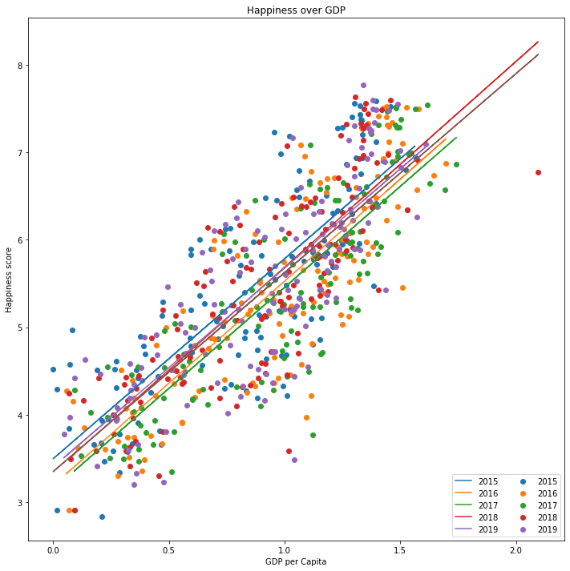

```python
#Let's plot some lines of best fits to see how they fit over the data
plt.subplots(figsize = (12,12))


# Use polyfit to help plot the line of best fit
for i in df.year.unique():
    x = df.loc[df['year'] == i]['gdp_per_cap']
    y = df.loc[df['year'] == i]['score']
    plt.scatter(x, y, label=i)

    x = np.array(df[df['year']== i]['gdp_per_cap'])
    y = np.array(df[df['year'] == i]['score'])
    m, b = np.polyfit(x,y, 1)
    plt.plot(x, m*x + b, label=i)
plt.xlabel("GDP per Capita")

plt.ylabel("Happiness score")
plt.title("Happiness over GDP")
plt.legend(loc='lower right', ncol=2)

# plt.show()
# plt.scatter(df.gdp_per_cap, df.score)
x = np.array(df.gdp_per_cap)
y = np.array(df.score)
m, b = np.polyfit(x,y, 1)
plt.plot(x, m*x + b, label='Overall')
```

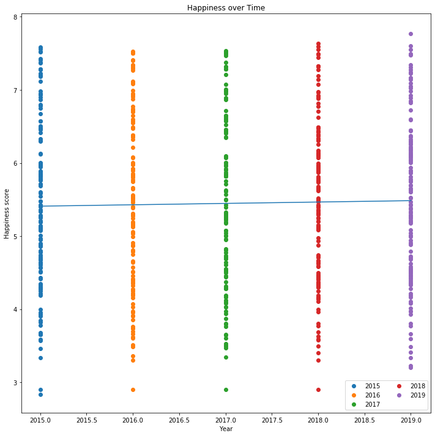

```python
# Let's try it with the scatter plot of happiness over time
plt.subplots(figsize = (12,12))

for i in df.year.unique():
    y = df.loc[df['year'] == i]['score']
    x = np.asarray([i]*len(y)).astype(float)

    plt.scatter(x, y, label=i)

plt.xlabel("Year")

plt.ylabel("Happiness score")
plt.title("Happiness over Time")
plt.legend(loc='lower right', ncol=2)

# plt.show()
# plt.scatter(df.gdp_per_cap, df.score)
x = np.array(df.year)
y = np.array(df.score)
m, b = np.polyfit(x,y, 1)
plt.plot(x, m*x + b, label='Overall')
```

Now let's look at our linear models and see what they can tell us.

```python
print("y = " + str(model.coef_[0]) + "x + " + str(model.intercept_))
```

```
y = 2.234847510996502x + 3.328006774514789
```

```python
print("2015: y = " + str(model15.coef_[0]) + "x + " + str(model.intercept_))
print("2016: y = " + str(model16.coef_[0]) + "x + " + str(model.intercept_))
print("2017: y = " + str(model17.coef_[0]) + "x + " + str(model.intercept_))
print("2018: y = " + str(model18.coef_[0]) + "x + " + str(model.intercept_))
print("2019: y = " + str(model19.coef_[0]) + "x + " + str(model.intercept_))
```

[output not shown]

# Conclusion

Every year too, we see that happiness is expected to increase as GDP increases.

You can predict that as your money grows so will your happiness! Sadly, this is likely not the full reality as there are many other factors at play in the dataset such as freedom of choices, generosity, family, and many other things. This was just one factor in a large net of life and it is impossible to say that the secret to happiness is money. However, I think it is fair to say that it probably would not hurt your chances.

Today we learned how to use violinplots, scatterplots, linear regression models, as well as modeling lines of best fit. Thank you for coming today and have fun exploring data science.